# Reproducible Research

## Course Project 1

### Loading and preprocessing data

Load the data with the following code.

```r
data <- read.csv("activity.csv")
```

### What is mean total number of steps taken per day?

1. Calculate the total number of steps taken per day.

```r
stepsperday <- tapply(data$steps, data$date, FUN=sum, na.rm=TRUE)
```

2. Make a histogram of the total number of steps taken each day

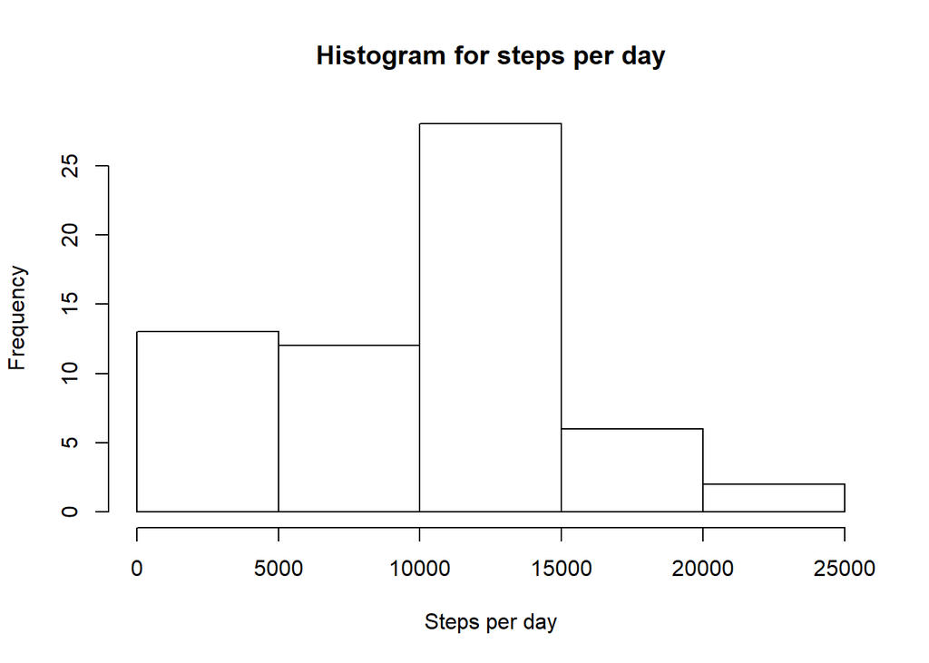

```r
hist(stepsperday,
     xlab="Steps per day",
     main="Histogram for steps per day")
```

3. Calculate and report the mean and median of the total number of steps taken per day

```r
mean_spd <- mean(stepsperday)
median_spd <- median(stepsperday)
```

The mean of the total number of steps taken per day is 9354.2295082 and the median 10395.

### What is the average daily activity pattern?

1. Make a time series plot of the 5-minute interval (x-axis) and the average number of steps taken, averaged across all days (y-axis).

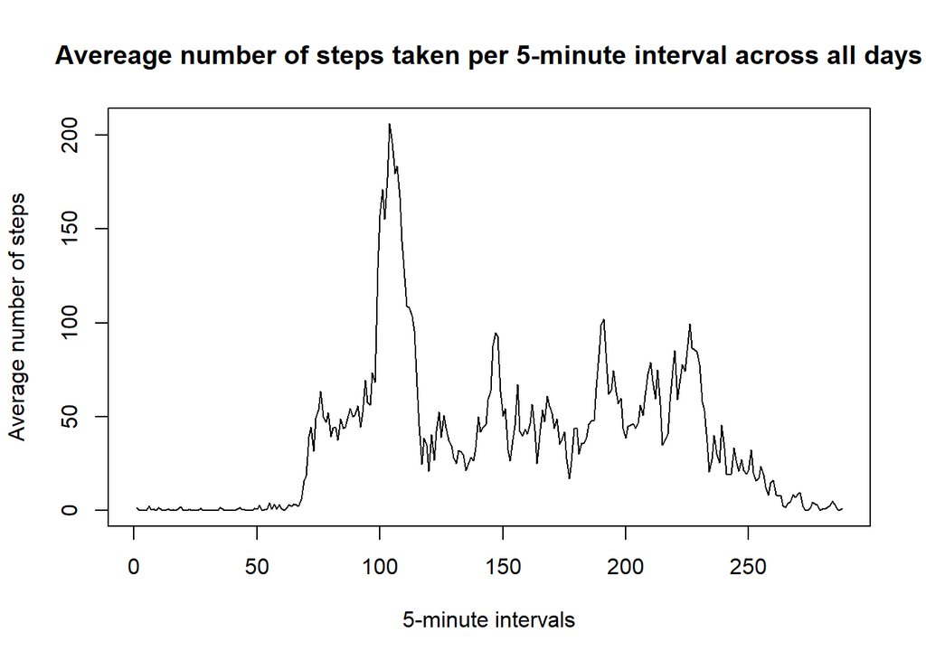

```r
meansteps_perint <- tapply(data$steps, data$interval, FUN=mean, na.rm=TRUE)

plot(meansteps_perint,
     type="l",
     xlab="5-minute intervals",
     ylab="Average number of steps",
     main="Avereage number of steps taken per 5-minute interval across all days")
```

2. Which 5-minute interval, on average across all the days in the dataset, contains the maximum number of steps?

```r
max_int_num <- which.max(meansteps_perint)
```

The 5-minute interval number 104 contains the maximum number of steps on average across all the days in the dataset.

### Imputing missing values

1. Calculate and report the total number of missing values in the dataset

```r
count_na <- sum(is.na(data$steps), is.na(data$date), is.na(data$interval))
```

The total number of missing values is 2304.

2. Devise a strategy for filling in all of the missing values in the dataset.

3. Create a new dataset that is equal to the original dataset but with the missing data filled in.

```r
library(data.table)

dataclean = as.data.table(data, keep.rownames=TRUE)

mean_info <- dataclean[,.(steps_mean=mean(steps, na.rm=TRUE)),interval]

setkey(dataclean, interval)
setkey(mean_info, interval)

dataclean <- merge(dataclean, mean_info, all.x=TRUE)

dataclean$steps_clean <- ifelse(
                          is.na(dataclean$steps),
                          dataclean$steps_mean,
                          dataclean$steps)
```

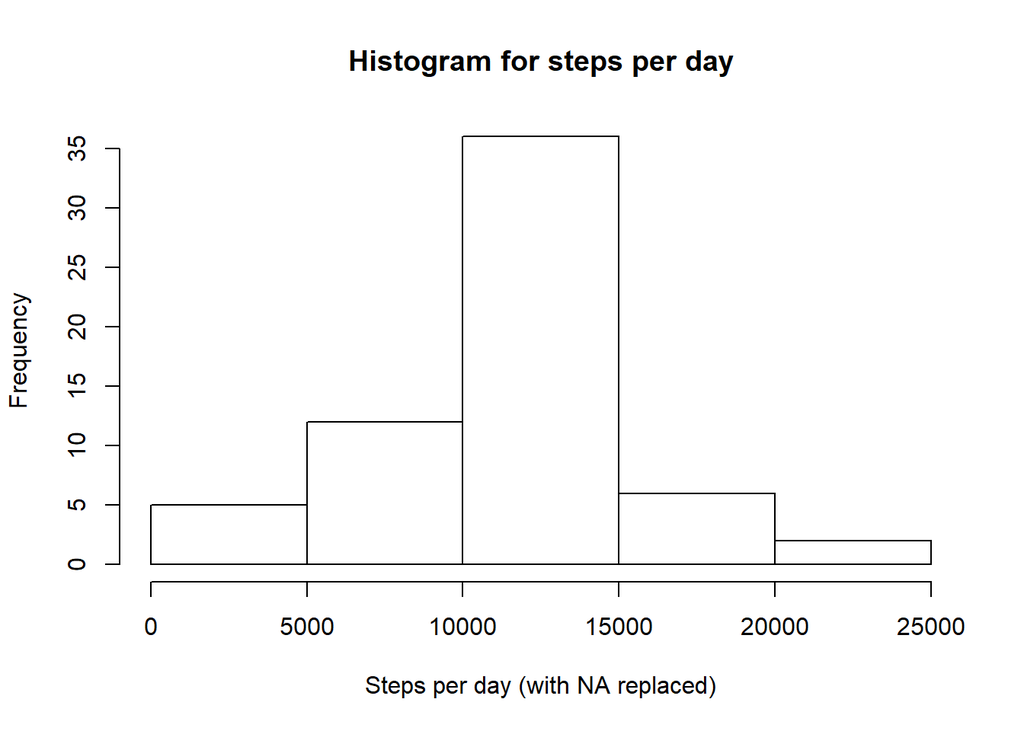

```r
stepsperday_clean <- tapply(dataclean$steps_clean, dataclean$date, FUN=sum)

hist(stepsperday_clean,
     xlab="Steps per day (with NA replaced)",
     main="Histogram for steps per day")
```

```r
mean_spd_clean <- mean(stepsperday_clean)

median_spd_clean <- median(stepsperday_clean)
```

### Are there differences in activity patterns between weekdays and weekends?

1. Create a new factor variable in the dataset with two levels - “weekday” and “weekend” indicating whether a given date is a weekday or weekend day.

```r
library(date)
dataclean$day <- weekdays(as.Date(dataclean$date))
dataclean$weekday <- ifelse(
                      dataclean$day %in% c("Samstag","Sonntag"),
                      "weekend",
                      "weekday")
```

2. Make a panel plot containing a time series plot of the 5-minute interval (x-axis) and the average number of steps taken, averaged across all weekday days or weekend days (y-axis).

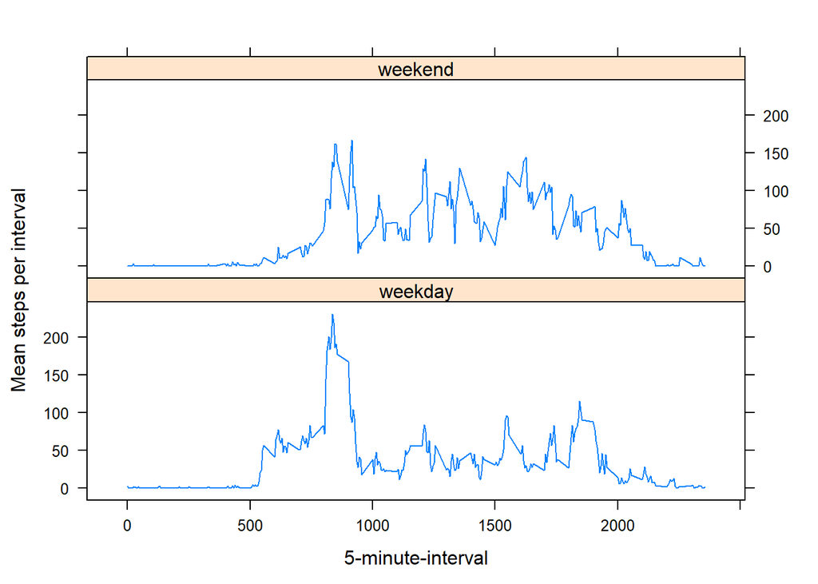

```r
cleanstepsperint <- aggregate(steps_clean ~ interval+weekday,
                              dataclean,mean)
xyplot(cleanstepsperint$steps_clean ~ cleanstepsperint$interval | cleanstepsperint$weekday,
      type="l",
      layout=c(1,2),
      xlab="5-minute-interval",
      ylab="Mean steps per interval")
```